# Assignment 2

Arshia Mahmoodi

## Assignment 1 Summary

### Selected dataset GSE135511

Working with a dataset that documents the pathological changes observed in grey matter in multiple sclerosis with augmented meningeal inflammation, but also demonstrates the actual pathways associated with this inflammatory response. This can be applied to genes involved in tumour signalling, which are are differentially regulated in multiple scleroris cases compared to the control.

We are observing 50 different motor-cortex tissue samples, 10 of which are non neurological control samples, derived from post-mortem multiple sclerosis brains.

Across these samples, 22303 rows of gene expression recorded and their respective value and p-value documented. Hence, the study has very good coverage of the data.

## Loading Required Packages

```r
if (! requireNamespace("BiocManager", quietly = TRUE)) {
    install.packages("BiocManager")
}

if (! requireNamespace("GEOquery", quietly = TRUE)) {
    BiocManager::install("GEOquery")
}

if (!requireNamespace("GEOmetadb", quietly = TRUE)){
    BiocManager::install("GEOmetadb")
}

if (!requireNamespace("edgeR", quietly = TRUE)){
    BiocManager::install("edgeR")
}
if (!requireNamespace("ComplexHeatmap")) {
  BiocManager::install("ComplexHeatmap")
}
if (!requireNamespace("circlize")) {
  BiocManager::install("circlize")
}
```

```r
library(GEOquery)

gse_name <- "GSE135511_RAW.tar"

if (!file.exists(gse_name)){
  gse <- getGEO("GSE135511", GSEMatrix = FALSE)
}

current_gpl <- names(GPLList(gse))[1]
current_gpl_info <- Meta(getGEO(current_gpl))
```

**Platform title:** Illumina HumanRef-8 v3.0 expression beadchip

**Submission date** May 21 2008

**Last update date:** Mar 20 2017

**Organisms:** Homo sapiens

**Number of GEO datasets that use this techology:** 227

**Number of GEO samples that use this technology:** 7092

## Regenerating the data from Assignment 1

```r
library(knitr)

sfiles = getGEOSuppFiles('GSE135511')

fnames = rownames(sfiles)

# Second supplementary file containing non-normalized data
supp = read.delim(fnames[2],header=TRUE,
                check.names = FALSE)
#head(supp)
kable(supp[1:10,1:10], format = "html")
```

| ID_REF | Control_A05-149 | Control_A05-149 : Detection Pval | Control_A05-58 | Control_A05-58 : Detection Pval | Control_A06-189 | Control_A06-189 : Detection Pval | Control_A06-65 | Control_A06-65 : Detection Pval | Control_C14 |
| --- | --- | --- | --- | --- | --- | --- | --- | --- | --- |
| ILMN_1802380 | 9.983321 | 0.0000000 | 10.066356 | 0.0000000 | 10.637364 | 0.0000000 | 10.672607 | 0.0000000 | 10.267357 |
| ILMN_1792389 | 9.351906 | 0.0000000 | 9.074273 | 0.0000000 | 9.814912 | 0.0000000 | 9.604907 | 0.0000000 | 9.904532 |
| ILMN_2375156 | 6.128371 | 0.1400602 | 5.849127 | 0.1641566 | 6.150781 | 0.1219880 | 6.008512 | 0.1942771 | 6.200614 |
| ILMN_1697642 | 8.752439 | 0.0000000 | 8.450157 | 0.0000000 | 8.971419 | 0.0000000 | 8.829816 | 0.0000000 | 8.110913 |
| ILMN_1681845 | 8.491746 | 0.0000000 | 8.160882 | 0.0000000 | 8.530636 | 0.0000000 | 8.534954 | 0.0000000 | 8.060524 |
| ILMN_1690979 | 6.376297 | 0.0256024 | 6.251915 | 0.0195783 | 6.257364 | 0.0647590 | 6.387394 | 0.0210843 | 6.183090 |
| ILMN_1811114 | 6.301253 | 0.0436747 | 6.838438 | 0.0030120 | 6.566935 | 0.0180723 | 7.604173 | 0.0015060 | 6.583020 |
| ILMN_1660729 | 6.002863 | 0.4021084 | 5.741170 | 0.3433735 | 6.003999 | 0.3012048 | 5.850627 | 0.4969879 | 6.096298 |
| ILMN_2129572 | 6.644665 | 0.0090361 | 6.553935 | 0.0075301 | 7.338169 | 0.0030120 | 8.226116 | 0.0000000 | 7.629032 |
| ILMN_1705659 | 6.008120 | 0.3855422 | 5.533683 | 0.8704819 | 5.882644 | 0.5948795 | 5.766493 | 0.7846386 | 5.993140 |

Dimensions of the data:

```r
dim(supp)
```

```
## [1] 22303   101
```

## P Value Table

```r
library(edgeR)
P_Values <- seq(3, 101, 2)

Values <- seq(2,101,2)

cpms = edgeR::cpm(supp[,2:101])
rownames(cpms) <- supp[,1]
keep = rowSums(cpms >1) >=3
supp_filtered = supp[keep,]

filtered_data_matrix <- as.matrix(supp_filtered[,2:51])

d = edgeR::DGEList(counts=filtered_data_matrix, group=supp[1,P_Values])

P_Value_Table <- supp[, P_Values]
Value_Table <-supp[,Values]

kable(P_Value_Table[1:10,1:50], format = "html")
```

| Control_A05-149 : Detection Pval | Control_A05-58 : Detection Pval | Control_A06-189 : Detection Pval | Control_A06-65 : Detection Pval | Control_C14 : Detection Pval | Control_C28 : Detection Pval | Control_C41 : Detection Pval | Control_CMS-RZ77 : Detection Pval | Control_CMS-RZ84 : Detection Pval | Control_CMS-RZ90 : Detection Pval | GML_Fneg_MS003 : Detection Pval | GML_Fneg_MS042 : Detection Pval | GML_Fneg_MS056 : Detection Pval | GML_Fneg_MS074 : Detection Pval | GML_Fneg_MS100 : Detection Pval | GML_Fneg_MS104 : Detection Pval | GML_Fneg_MS114 : Detection Pval | GML_Fneg_MS127 : Detection Pval | GML_Fneg_MS163 : Detection Pval | GML_Fneg_MS200 : Detection Pval | GML_Fpos_MS079 : Detection Pval | GML_Fpos_MS092 : Detection Pval | GML_Fpos_MS121 : Detection Pval | GML_Fpos_MS136 : Detection Pval | GML_Fpos_MS153 : Detection Pval | GML_Fpos_MS154 : Detection Pval | GML_Fpos_MS160 : Detection Pval | GML_Fpos_MS176 : Detection Pval | GML_Fpos_MS180 : Detection Pval | GML_Fpos_MS234 : Detection Pval | … |
| --- | --- | --- | --- | --- | --- | --- | --- | --- | --- | --- | --- | --- | --- | --- | --- | --- | --- | --- | --- | --- | --- | --- | --- | --- | --- | --- | --- | --- | --- | --- |
| 0.0000000 | 0.0000000 | 0.0000000 | 0.0000000 | 0.0000000 | 0.0000000 | 0.0000000 | 0.0000000 | 0.0000000 | 0.0000000 | 0.0000000 | 0.0000000 | 0.0000000 | 0.0000000 | 0.0000000 | 0.0000000 | 0.0000000 | 0.0000000 | 0.0000000 | 0.0000000 | 0.0000000 | 0.0000000 | 0.0000000 | 0.0000000 | 0.0000000 | 0.0000000 | 0.0000000 | 0.0000000 | 0.0000000 | 0.0000000 | … |
| 0.0000000 | 0.0000000 | 0.0000000 | 0.0000000 | 0.0000000 | 0.0000000 | 0.0000000 | 0.0000000 | 0.0000000 | 0.0000000 | 0.0000000 | 0.0000000 | 0.0000000 | 0.0000000 | 0.0000000 | 0.0000000 | 0.0000000 | 0.0000000 | 0.0000000 | 0.0000000 | 0.0000000 | 0.0000000 | 0.0000000 | 0.0000000 | 0.0000000 | 0.0000000 | 0.0000000 | 0.0000000 | 0.0000000 | 0.0000000 | … |
| 0.1400602 | 0.1641566 | 0.1219880 | 0.1942771 | 0.0406626 | 0.0180723 | 0.0301205 | 0.0557229 | 0.1204819 | 0.1159639 | 0.0843374 | 0.0240964 | 0.0481928 | 0.0512048 | 0.0346386 | 0.1521084 | 0.1430723 | 0.2349398 | 0.0933735 | 0.0813253 | 0.1912651 | 0.0301205 | 0.0647590 | 0.0225904 | 0.1957831 | 0.0542169 | 0.1551205 | 0.0888554 | 0.0557229 | 0.1069277 | … |
| 0.0000000 | 0.0000000 | 0.0000000 | 0.0000000 | 0.0000000 | 0.0000000 | 0.0000000 | 0.0000000 | 0.0000000 | 0.0000000 | 0.0000000 | 0.0000000 | 0.0000000 | 0.0000000 | 0.0000000 | 0.0000000 | 0.0000000 | 0.0015060 | 0.0000000 | 0.0000000 | 0.0000000 | 0.0000000 | 0.0000000 | 0.0000000 | 0.0000000 | 0.0000000 | 0.0000000 | 0.0000000 | 0.0000000 | 0.0000000 | … |
| 0.0000000 | 0.0000000 | 0.0000000 | 0.0000000 | 0.0000000 | 0.0000000 | 0.0000000 | 0.0000000 | 0.0000000 | 0.0000000 | 0.0000000 | 0.0000000 | 0.0000000 | 0.0000000 | 0.0000000 | 0.0000000 | 0.0000000 | 0.0015060 | 0.0000000 | 0.0000000 | 0.0000000 | 0.0000000 | 0.0000000 | 0.0000000 | 0.0000000 | 0.0000000 | 0.0000000 | 0.0000000 | 0.0000000 | 0.0000000 | … |
| 0.0256024 | 0.0195783 | 0.0647590 | 0.0210843 | 0.0496988 | 0.0783132 | 0.0602410 | 0.1024096 | 0.0195783 | 0.0527108 | 0.0421687 | 0.0361446 | 0.0692771 | 0.0406626 | 0.0376506 | 0.0421687 | 0.0331325 | 0.0346386 | 0.0557229 | 0.0632530 | 0.0496988 | 0.0195783 | 0.0587349 | 0.1460843 | 0.0391566 | 0.0286145 | 0.0286145 | 0.0527108 | 0.0647590 | 0.0451807 | … |
| 0.0436747 | 0.0030120 | 0.0180723 | 0.0015060 | 0.0105422 | 0.0090361 | 0.0075301 | 0.0105422 | 0.0361446 | 0.0090361 | 0.0075301 | 0.0015060 | 0.0075301 | 0.0075301 | 0.0677711 | 0.0045181 | 0.1099398 | 0.0045181 | 0.0075301 | 0.0045181 | 0.0858434 | 0.0316265 | 0.0090361 | 0.0045181 | 0.0421687 | 0.0286145 | 0.0000000 | 0.0165663 | 0.0030120 | 0.0075301 | … |
| 0.4021084 | 0.3433735 | 0.3012048 | 0.4969879 | 0.0828313 | 0.0256024 | 0.1189759 | 0.7484940 | 0.5933735 | 0.4171687 | 0.4096386 | 0.0331325 | 0.2545181 | 0.5225903 | 0.1897590 | 0.2409639 | 0.2740964 | 0.3072289 | 0.1280120 | 0.5316265 | 0.5768072 | 0.0843374 | 0.1189759 | 0.7334337 | 0.4969879 | 0.4698795 | 0.2695783 | 0.4201807 | 0.2500000 | 0.2379518 | … |
| 0.0090361 | 0.0075301 | 0.0030120 | 0.0000000 | 0.0015060 | 0.0015060 | 0.0015060 | 0.0015060 | 0.0105422 | 0.0015060 | 0.0000000 | 0.0000000 | 0.0015060 | 0.0000000 | 0.0090361 | 0.0015060 | 0.0466868 | 0.0015060 | 0.0000000 | 0.0030120 | 0.0000000 | 0.0030120 | 0.0015060 | 0.0000000 | 0.0045181 | 0.0015060 | 0.0000000 | 0.0015060 | 0.0015060 | 0.0015060 | … |
| 0.3855422 | 0.8704819 | 0.5948795 | 0.7846386 | 0.1897590 | 0.1024096 | 0.1250000 | 0.3132530 | 0.2409639 | 0.3825301 | 0.5045181 | 0.1325301 | 0.2168675 | 0.0466868 | 0.1731928 | 0.3674699 | 0.5000000 | 0.2319277 | 0.8207831 | 0.3614458 | 0.0692771 | 0.2771084 | 0.2364458 | 0.0798193 | 0.2575301 | 0.5557229 | 0.1611446 | 0.5015060 | 0.2484940 | 0.2259036 | … |

We will test the number of genes that pass a threshold of p = 0.05, as it is generally accepeted to be representative of significance. This value indicates that there is a <5% chance that are results could be obtained from chance.

```r
sum(P_Value_Table < 0.05)
```

```
## [1] 655431
```

This is the total number of observations for all 22303 genes across all 50 samples that had a p_value score of less than 0.05.

## Sampling and Multiple Hypothesis Testing

```r
samples <- data.frame(lapply(colnames(Value_Table),
                             FUN=function(x){unlist(strsplit(x, split = "\\_"))[c(2,3,4)]}))

colnames(samples) <- colnames(Value_Table)

rownames(samples) <- c("Control","Inflammation","No_Inflammation")

samples <- data.frame(t(samples))
```

### The T-Test

One possible multiple hypothesis test that we could use is a T-test to check for significant differences between two of the test conditions. We can try to use the T-test to check for a significant difference between MS brains with and without inflammation firstly.

```r
t.test(Value_Table[11], Value_Table[31])
```

```
##
##  Welch Two Sample t-test
##
## data:  Value_Table[11] and Value_Table[31]
## t = 12.759, df = 44426, p-value < 2.2e-16
## alternative hypothesis: true difference in means is not equal to 0
## 95 percent confidence interval:
##  0.1479742 0.2016897
## sample estimates:
## mean of x mean of y
##  7.035899  6.861067
```

```r
t.test(Value_Table[1], Value_Table[11])
```

```
##
##  Welch Two Sample t-test
##
## data:  Value_Table[1] and Value_Table[11]
## t = 10.283, df = 44414, p-value < 2.2e-16
## alternative hypothesis: true difference in means is not equal to 0
## 95 percent confidence interval:
##  0.1216445 0.1789394
## sample estimates:
## mean of x mean of y
##  7.186191  7.035899
```

As well as the control against MS brains without Inflammation

```r
t.test(Value_Table[1], Value_Table[31])
```

```
##
##  Welch Two Sample t-test
##
## data:  Value_Table[1] and Value_Table[31]
## t = 22.89, df = 43883, p-value < 2.2e-16
## alternative hypothesis: true difference in means is not equal to 0
## 95 percent confidence interval:
##  0.2972839 0.3529640
## sample estimates:
## mean of x mean of y
##  7.186191  6.861067
```

In all cases, we have that p-value < 2.2e-16, hence using a threshold of even 0.01, we are very confident that the difference in mean between the test conditions are statisically different.

Since we have 3 test conditions to compare, we could have also considered doncuting a the three-way anova, or Ancova, test in R.

## Differentially Expressed Genes

We can generate an MA Plot to have a look at the differentially expressed genes in our samples

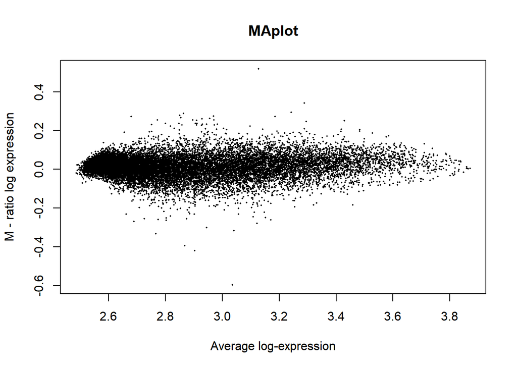

```r
plotMA(log2(Value_Table), ylab= "M - ratio log expression",
       main="MAplot")
```

```r
#volcanoplot(x = log2([Value_Table), y = P_Value_Table)
```

## HeatMap

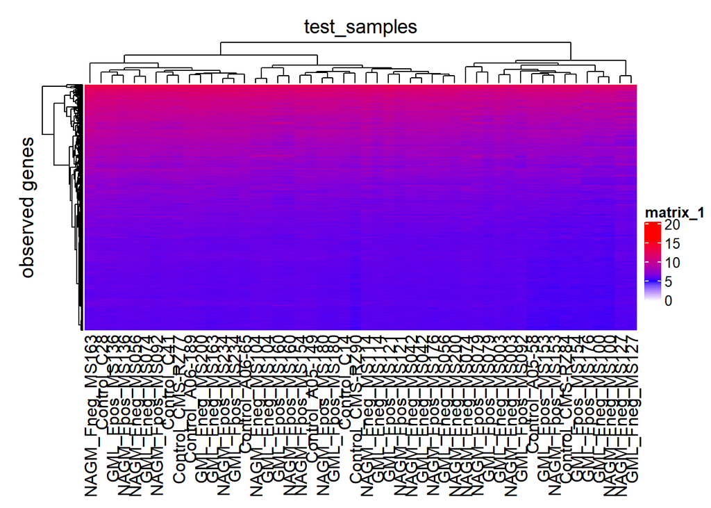

```r
library("ComplexHeatmap")
library("circlize")
matrix <- Value_Table
rownames(matrix) <- rownames(supp)
colnames(matrix) <- colnames(Value_Table)

if(min(matrix) == 0) {
  heatmap_col = colorRamp2(c(0, max(matrix)), c("white", "red"))
} else {
  heatmap_col = colorRamp2(c(min(matrix), 0, max(matrix)), c("blue", "white", "red"))
}

heatmap <- Heatmap(as.matrix(matrix),
                           show_row_dend = TRUE,
                           show_column_dend = TRUE,
                           col= heatmap_col,
                           show_column_names = TRUE,
                           show_row_names = FALSE,
                           show_heatmap_legend = TRUE,
                           row_title = "observed genes",
                           column_title = "test_samples"
)

heatmap
```

## Threshold over-representation Anylsis

```r
filtered_data_matrix <- as.matrix(supp[2:2203,Values])
#rownames(filtered_data_matrix) <- supp[2:2203,1]
d = DGEList(counts=filtered_data_matrix, group=supp[1,Values])
d = calcNormFactors(d)
model_design <- model.matrix(~ filtered_data_matrix)
d <- estimateDisp(d, model_design)

fit <- glmQLFit(d, model_design)
qlf.pos_vs_neg <- glmQLFTest(fit, model_design)

qlf_output_hits <- topTags(qlf.pos_vs_neg,sort.by = "PValue",
                           n = nrow(filtered_data_matrix))

length(which(qlf_output_hits$table$PValue < 0.05
            & qlf_output_hits$table$logFC > 0))

length(which(qlf_output_hits$table$PValue < 0.05
            & qlf_output_hits$table$logFC < 0))

qlf_output_hits_withgn <- merge(ca125_exp[,1:2],qlf_output_hits, by.x=1, by.y = 0)
qlf_output_hits_withgn[,"rank"] <- -log(qlf_output_hits_withgn$PValue,base =10) * sign(qlf_output_hits_withgn$logFC)
qlf_output_hits_withgn <- qlf_output_hits_withgn[order(qlf_output_hits_withgn$rank),]
upregulated_genes <- qlf_output_hits_withgn$gname[  which(qlf_output_hits_withgn$PValue < 0.05
             & qlf_output_hits_withgn$logFC > 0)]
downregulated_genes <- qlf_output_hits_withgn$gname[
  which(qlf_output_hits_withgn$PValue < 0.05
             & qlf_output_hits_withgn$logFC < 0)]
write.table(x=upregulated_genes,
            file=file.path("data","ca125_upregulated_genes.txt"),sep = "\t",
            row.names = FALSE,col.names = FALSE,quote = FALSE)
write.table(x=downregulated_genes,
            file=file.path("data","ca125_downregulated_genes.txt"),sep = "\t",
            row.names = FALSE,col.names = FALSE,quote = FALSE)
```

[output not shown]

In general, we are generate a thresholded list from the list of all genes in our samples as the strong signal may be indicative of genes of significance.

Once we generate a list of up-regulated and down-regulated genes, we can analyze the lists separately, or alotogether, using tools such as g-profiler as previously mentioned.

## Interpertation

In addition to this study, there have been multiple other gene profiling experiments that have arrived at a similair conclusion to the one presented in this paper.

A study by Hendrickx et al. in 2017, used gene profile expression discovered the up regulation of genes relating to lipid binding, lipid uptake in areas of MS lesion. Additionally, they observed down regulation of scavenger receptors that resulted in reduced myelin uptake.

## References

1. Magliozzi R, Howell OW, Durrenberger P, Aricò E et al. Meningeal inflammation changes the balance of TNF signalling in cortical grey matter in multiple sclerosis. J Neuroinflammation 2019 Dec 7;16(1):259. PMID: 31810488
2. Hendrickx, Debbie A E et al. “Gene Expression Profiling of Multiple Sclerosis Pathology Identifies Early Patterns of Demyelination Surrounding Chronic Active Lesions.” Frontiers in immunology vol. 8 1810. 21 Dec. 2017, doi:10.3389/fimmu.2017.01810

Note: R code for this report was written following lecture notes in BCB420